# Case Study: Adolescent Meal-replacement Weight-Control Study

Here, we present a case study for outcome regression method with the simulated bmiDataOne dataset.

To get the package ready, here are the few steps needed. Clean up the workspace:

```r
rm(list = ls())
```

Install the package:

```r
install.packages('DynTxRegime')
```

Load the package:

```r
library(DynTxRegime)
```

The dataset bmiDataOne is excerpted from the bmiData in the DynTxRegime package to mimic a single-stage SMART of body mass index (BMI) reduction with two treatment options at the decision point. The full dataset bmiData was generated based on a clinical trial studying the effect of meal replacements on weight loss and BMI reduction in obese adolescents; see Berkowitz et al. (2010) for a complete description of the original randomized trial.

In the dataset bmiDataOne, the baseline covariates include the following information of the patient: gender (gender), race (race), his/er parent’s BMI (parentBMI), baseline BMI(baselineBMI). Each patient’s treatment at the decision point (A1) is included. The treatment was randomized to meal replacement (MR) or conventional diet (CD) at the single stage with probability 0.5. His/er BMI collected after 4-month treatment (month4BMI) is also included. This generated dataset is complete, as we implement the method after missing data have been imputed appropriately.

Here is a glimpse of the dataset.

```r
# Data
head(bmiDataOne)
```

```
##   gender race parentBMI baselineBMI month4BMI A1
## 1      0    1  31.59683    35.84005  34.22717 CD
## 2      1    0  30.17564    37.30396  36.38014 CD
## 3      1    0  30.27918    36.83889  34.42168 MR
## 4      1    0  27.49256    36.70679  32.52011 CD
## 5      1    1  26.42350    34.84207  33.72922 CD
## 6      0    0  29.30970    36.68640  32.06622 MR
```

Then, we still have several small steps to get the dataset ready for us to carry out the outcome regression method using qLearn function in the package. We need to recast treatment variables A1 to (0, 1). Meal replacement is coded as 1, and conventional diet is coded as 0.

```r
#----------------------------------------------------#
# Recast treatment variables to (0,1)
#----------------------------------------------------#
bmiDataOne$A1[which (bmiDataOne$A1=="MR")] <- 1L
bmiDataOne$A1[which (bmiDataOne$A1=="CD")] <- 0L
bmiDataOne$A1 <- as.integer(bmiDataOne$A1)
```

Moreover, we define the response y to be the negative 4 month change in BMI from baseline, which is formulated as $-100 \times \frac{month4BMI - baselineBMI}{ baselineBMI}$.

```r
#----------------------------------------------------#
# Define response y to be the negative 4 month
# change in BMI from baseline
#----------------------------------------------------#
bmiDataOne$y <- -100*(bmiDataOne[,5] - bmiDataOne[,4])/bmiDataOne[,4]
```

As we have the data ready, it comes to modeling the Q-functions in the outcome regression method. We use the modeling with the form of
$$Q(\boldsymbol{x}, a)= m(\boldsymbol{x}_0;\boldsymbol{\beta}) + a\cdot c(\boldsymbol{x}_1;\boldsymbol{\gamma}),$$
where the main effect and the contrast (or treatment effect) are modeled seperately.

We use the buildModelObj function to create a modeling object for the main effect component, named moMain.

```r
#----------------------------------------------------#
# Create modeling object for main effect component
#----------------------------------------------------#
moMain <- buildModelObj(model = ~ gender + race + parentBMI + baselineBMI, solver.method='lm')
```

The covariates included in moMain modeling object are gender, race, parentBMI and baselineBMI. solver.method is used to specify the method for fitting models, and ‘lm’ is used here.

Then, we creat a modeling object for the constrast component, called moCont, using buildModelObj function as well.

```r
#----------------------------------------------------#
# Create modeling object for contrast component
#----------------------------------------------------#
moCont <- buildModelObj(model = ~ gender + parentBMI, solver.method='lm')
```

The covariates included in moCont modeling are gender and parentBMI. Argument solver.method is set to be the same method ‘lm’ .

For both moMain and moCont, we used linear models. However, modeling is not restricted to linear models and is flexible. Non-linear models can also be used in the function buildModelObj.

Now, we are ready to estimate the optimal treatment regime using the function qLearn. In one-stage Q-learning, we regress the outcome y on baseline covariates and treatment using the two models built above, and then estimate the optimal decision rule for the single decision point. Follow the sample code below, we can achieve this purpose.

```r
#----------------------------------------------------#
# single stage fitting in Q-learning
#----------------------------------------------------#
fitQ1 <- qLearn(moMain = moMain, moCont = moCont,  response = bmiDataOne$y,  data = bmiDataOne, txName = "A1")
```

```
##
##
## Step  1  of Q-learning algorithm.
##
##
## qLearn(moMain = moMain, moCont = moCont, data = bmiDataOne, response = bmiDataOne$y,
##     txName = "A1")
##
##
##  *** Combined Fit ***
##
## Call:
## lm(formula = YinternalY ~ gender + race + parentBMI + baselineBMI +
##     A1 + gender:A1 + parentBMI:A1, data = data)
##
## Coefficients:
##  (Intercept)        gender          race     parentBMI   baselineBMI
##     -11.3591       -0.6782       -0.3126       -0.1873        0.6790
##           A1     gender:A1  parentBMI:A1
##      32.6196        1.2204       -1.0579
##
## Mean of Value Function:  9.098838
```

Arguments moMain and moCont are set to be the modeling object moMain and moCont we created above. Argument data is used to specify the object of class data.frame containing the covariates and treatment histories, which is bmiDataOne here. Argument response is the vector outcome of interest, bmiDataOne$y here. Argument txName is set to be the column header of data containing the treatment variable, “A1” here.

Once the one-stage Q-function is fitted, we can use functions coef and residuals to extract the coeffients of the regression and its corresponding residuals.

```r
# Coefficients of regressions
coef(fitQ1)
```

```
## $Combined
##  (Intercept)       gender         race    parentBMI  baselineBMI
##  -11.3591172   -0.6781783   -0.3126222   -0.1872530    0.6790194
##           A1    gender:A1 parentBMI:A1
##   32.6196161    1.2203803   -1.0579467
```

```r
# Residuals
head(residuals(fitQ1))
```

```
## [1] -2.247522 -5.165872 -2.551823  3.666467 -3.166655  2.918882
```

The function plot generates standard plots for diagnostics.

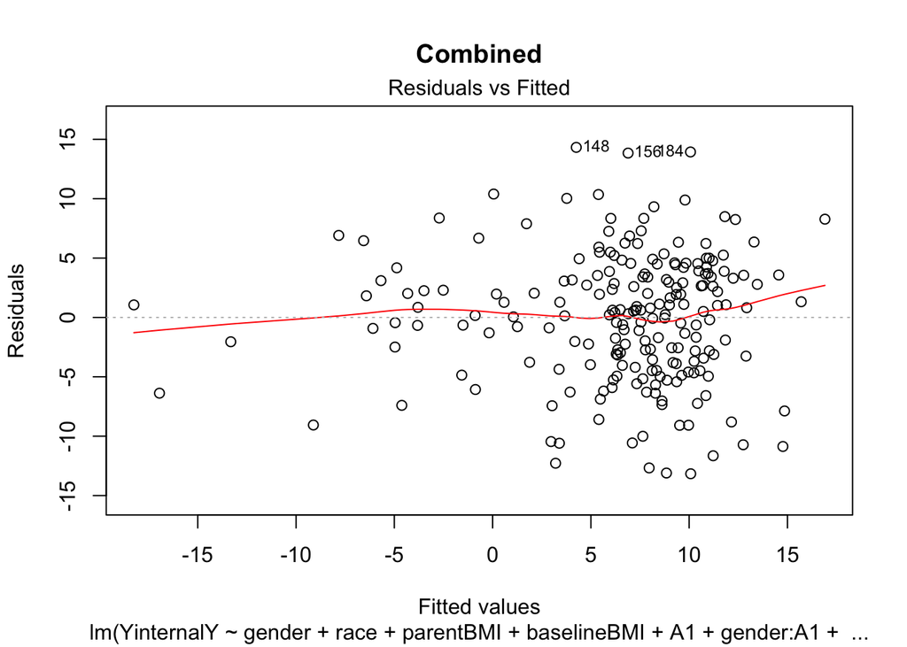

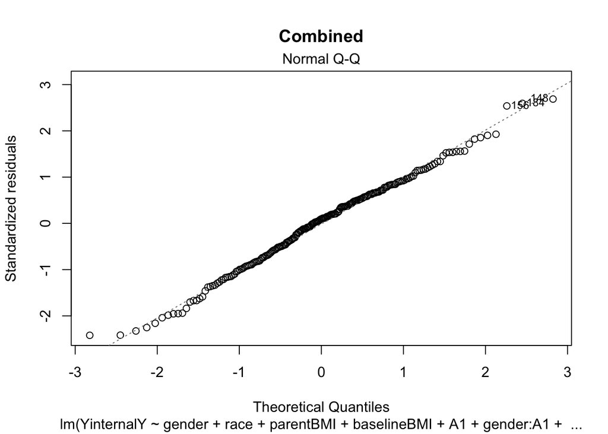

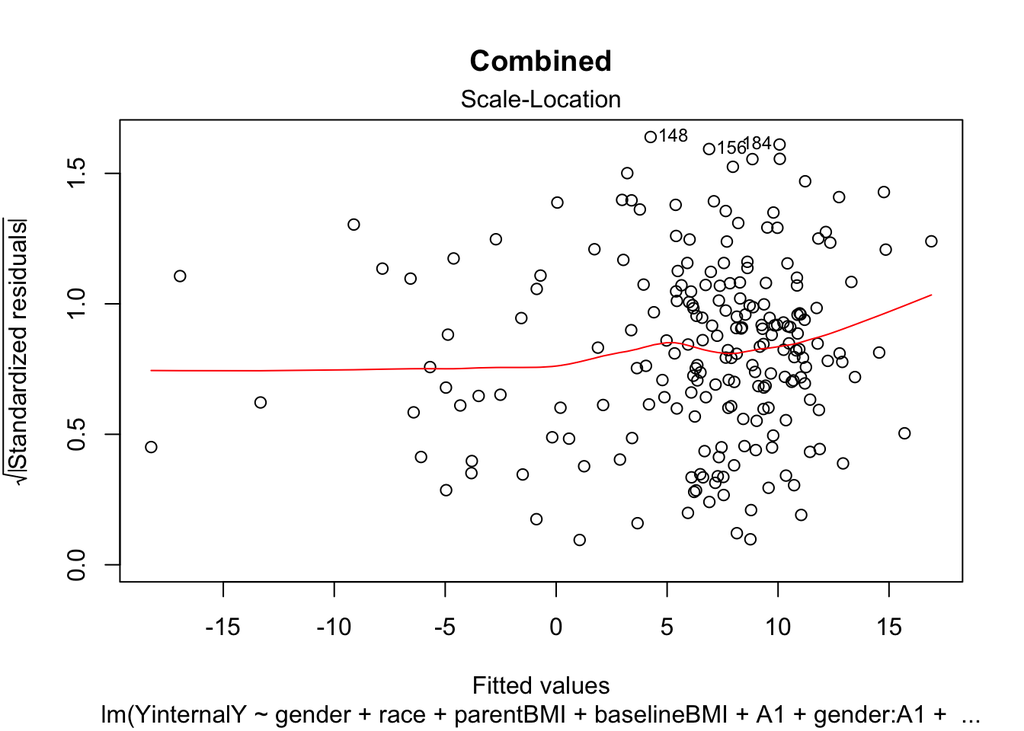

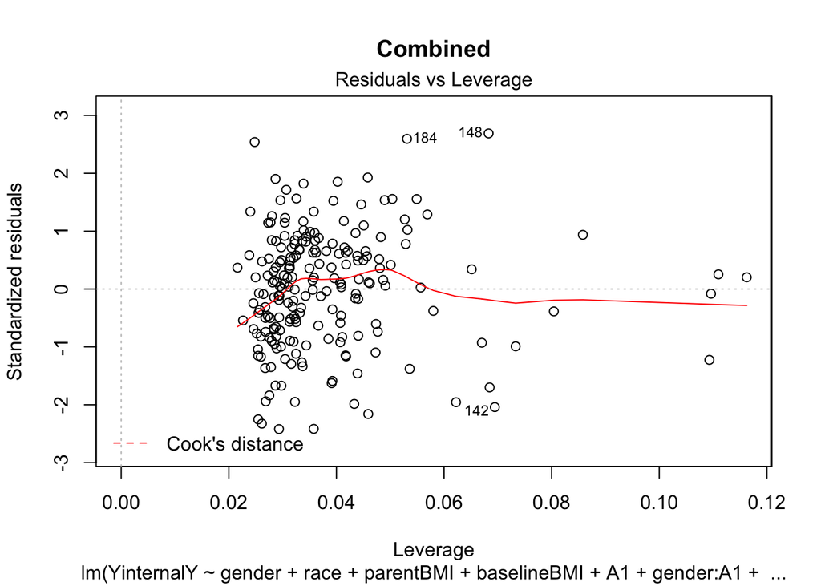

```r
#Plots
plot(fitQ1)
```

The function estimator returns the mean predicted outcome if estimated optimal treatment is followed by all patients in the training data.

```r
# mean predicted outcome
estimator(fitQ1)
```

```
## [1] 9.098838
```

For each subject in the training data, we can use the function qFuncs to obtain the estimated Q-functions for each treatment options.

```r
# estimated Q-functions
head(qFuncs(fitQ1))
```

```
##             0         1
## [1,] 6.747748  5.939599
## [2,] 7.642337  9.558118
## [3,] 7.307159  9.113395
## [4,] 7.739260 12.493588
## [5,] 6.360642 12.245979
## [6,] 8.063330  9.674842
```

Moreover, we can use the optTx function to obtain the predicted optimal treatments for new patients if their treatments were assigned based on our estimated optimal regime. For instance, we have prepared a small dataset, named bmiDataTwo, with 5 patients. We can call optTx to apply the estimated optimal regime in the fitQ1 object to this testing dataset.

```r
# New test dataset
bmiDataTwo
```

```
##   gender race parentBMI baselineBMI month4BMI A1           y
## 1      1    0  32.52664    35.02342  34.78497  1   0.6808512
## 2      1    0  32.44045    32.41054  37.28242  0 -15.0317995
## 3      0    1  28.98340    37.16185  30.09309  0  19.0215293
## 4      1    0  27.64180    36.02840  27.99559  0  22.2957578
## 5      0    0  25.20014    30.77888  30.29124  1   1.5843361
```

```r
# Retreive the predicted optimal treatments
optTx(fitQ1, bmiDataTwo)
```

```
## $qFunctions
##             0         1
## [1,] 5.653576  5.082115
## [2,] 3.895516  3.415247
## [3,] 8.134645 10.091367
## [4,] 7.250672 11.847114
## [5,] 4.821540 10.780755
##
## $optimalTx
## [1] 0 0 1 1 1
```